# Master of Data Science Capstone Proposal

# BC Stats

# Work Employment Survey Analysis

#### Team: Aaron Quinton, Fan Nie, Ayla Pearson

#### Mentor: Varada Kolhatkar

# Executive Summary

# Research Questions

# Objectives & Deliverables

1. Topic Modeling
   - Python model for future labelling
2. Percentage Agreement
   - Report
3. Descriptive Statistics
   - Python dashboard

# Quantitative Data

- 80 multiple choice questions with 5-point scale
- responses are aggregated into 17 main themes
  - scores are averaged over 100
- data ranges from 2007 to 2018
- 84% of employees took the survey in 2018

```r
head(df_select_quant)
```

| Engagement_07 | Engagement_08 | Engagement_09 | Engagement_10 | Engagement_11 | Engagement_13 | Engagement_15 | Engagement_18 | Commitment_07 | Commitment_08 | ⋯ | Supervisory_Level_10 | Supervisory_Level_11 | Supervisory_Level_15 | Supervisory_Level_18 | Job_Suitability_11 | Job_Suitability_13 | Job_Suitability_15 | Job_Suitability_18 | Tools_Workspace_15 | Tools_Workspace_18 |
| --- | --- | --- | --- | --- | --- | --- | --- | --- | --- | --- | --- | --- | --- | --- | --- | --- | --- | --- | --- | --- |
| 91.66667 | 62.50000 | 70.8333333333333 | 66.66667 | NA | 70.83333 | 58.33333 | 91.66667 | 100 | 62.5 | ⋯ | 50 | 75 | 30 | 85 | 75 | 75.0 | 87.5 | 100.0 | 66.66667 | 75.00000 |
| 79.16667 | 100.00000 | 91.6666666666667 | 100.00000 | 75.00000 | 83.33333 | 75.00000 | 75.00000 | 62.5 | 100.0 | ⋯ | 50 | 50 | 75 | 70 | 87.5 | 100.0 | 100.0 | 87.5 | 66.66667 | 91.66667 |
| 62.50000 | 66.66667 | 25 | 66.66667 | 70.83333 | 70.83333 | 79.16667 | 79.16667 | 62.5 | 75.0 | ⋯ | 25 | 50 | 80 | 75 | 75 | 75.0 | 75.0 | 87.5 | 58.33333 | 58.33333 |
| NA | NA |  | NA | NA | 66.66667 | 75.00000 | 75.00000 |  | NA | ⋯ |  | NA | 75 | 75 |  | 75.0 | 75.0 | 75.0 | 58.33333 | 75.00000 |
| 75.00000 | 20.83333 | 25 | 75.00000 | 75.00000 | 75.00000 | 75.00000 | 66.66667 | 75 | 12.5 | ⋯ | 87.5 | 75 | 75 | 75 | 75 | 87.5 | 62.5 | 75.0 | 75.00000 | 75.00000 |
| 75.00000 | 75.00000 |  | 58.33333 | 75.00000 | NA | 62.50000 | 75.00000 | 75 | 75.0 | ⋯ | 100 | 75 | 65 | 70 | 75 | NA | 75.0 | 75.0 | 25.00000 | NA |

```r
df_select_quant_nona<-df_select_quant %>% drop_na()
head(df_select_quant_nona)
```

[output not shown]

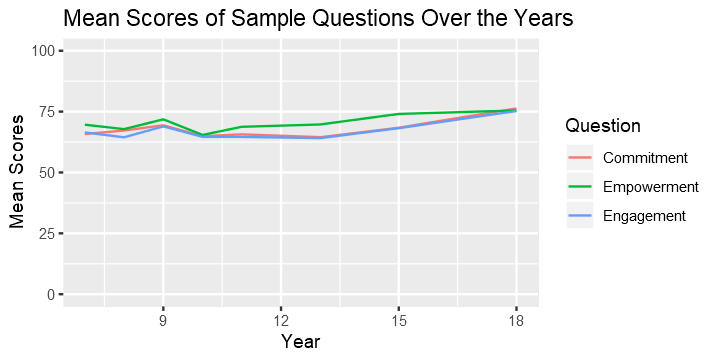

```r
plot
```

# Qualitative Data

#### Whats **one thing** would you like your organization to focus on to improve your work environment?

Coded into:

- 13 main themes
- 61 sub topics

[figure not shown]

Reference BC Public Service WES Results

# Topic Modeling

- Build LDA model to categorize future WES results
- data is labeled = simple method for measuring accuracy
- challenges
  - large number of subtopics
  - comments can contain from 1 to 5 topics

# Percentage Agreement

- preform sentiment and emotional analysis on qualitative results
- look at the correlation between the sentiment of the qualitative and quantitative results to see how they correspond
- help to reinforce the qualitative results
- generate report describing and visualizing results

# Descriptive Statistics

- longitudinal study across the quantitative data
- visualize the 17 themes over time at various scales:
  - organizational
  - ministry
- Python Dashboard made with plotly's Dash

[figure not shown]

# Time line

[figure not shown]